# S203_BENKHERFELLAH_IKKEN

📘 Projet : SAÉ 2.03 – Régression sur données réelles

Étudiant 1 :

- **Nom :** BENKHERFELLAH
- **Prénom :** Ibrahim

Étudiant 2 :

- **Nom :** IKKEN
- **Prénom :** Lysa

**Groupe :** Praxis 2  
**Département** : Science des Données  
**Établissement :** Université Sorbonne Paris Nord – IUT de Villeuniversité\

**Date** : Mai 2025

```
Le fichier data comporte 569 lignes
Ainsi que 32 colonnes
```

# Voici un petit descriptif des différentes colonnes

## Colonnes du fichier

| Colonne | Traduction en français | Description |
| --- | --- | --- |
| `id` | Identifiant | Numéro unique d'identification du patient. |
| `diagnosis` | Diagnostic | Résultat du diagnostic : M = Malin (cancer), B = Bénin (non cancéreux). |

## Caractéristiques morphologiques des tumeurs

### Moyennes (`*_mean`)

| Colonne | Traduction en français | Description |
| --- | --- | --- |
| `radius_mean` | Rayon moyen | Distance moyenne du centre vers le bord de la tumeur. |
| `texture_mean` | Texture moyenne | Variation des niveaux de gris (granularité de l’image). |
| `perimeter_mean` | Périmètre moyen | Périmètre moyen de la tumeur. |
| `area_mean` | Surface moyenne | Surface occupée par la tumeur. |
| `smoothness_mean` | Lissage moyen | Régularité des contours. |
| `compactness_mean` | Compacité moyenne | Mesure de la compacité des contours. |
| `concavity_mean` | Concavité moyenne | Gravité des zones concaves dans les contours de la tumeur. |
| `concave points_mean` | Points concaves moyens | Nombre moyen de points concaves. |
| `symmetry_mean` | Symétrie moyenne | Mesure de la symétrie de la tumeur. |
| `fractal_dimension_mean` | Dimension fractale moyenne | Complexité du contour (valeurs proches de 1 indiquent une forme simple). |

### Écart-type (`*_se`)

| Colonne | Traduction en français | Description |
| --- | --- | --- |
| `radius_se` | Écart-type du rayon | Variation du rayon. |
| `texture_se` | Écart-type de la texture | Variation de la texture. |
| `perimeter_se` | Écart-type du périmètre | Variation du périmètre. |
| `area_se` | Écart-type de la surface | Variation de la surface. |
| `smoothness_se` | Écart-type du lissage | Variation du lissage. |
| `compactness_se` | Écart-type de la compacité | Variation de la compacité. |
| `concavity_se` | Écart-type de la concavité | Variation de la concavité. |
| `concave points_se` | Écart-type des points concaves | Variation du nombre de points concaves. |
| `symmetry_se` | Écart-type de la symétrie | Variation de la symétrie. |
| `fractal_dimension_se` | Écart-type de la dimension fractale | Variation de la dimension fractale. |

### Valeurs extrêmes (`*_worst`)

| Colonne | Traduction en français | Description |
| --- | --- | --- |
| `radius_worst` | Rayon maximal | Valeur maximale du rayon. |
| `texture_worst` | Texture maximale | Valeur maximale de la texture. |
| `perimeter_worst` | Périmètre maximal | Valeur maximale du périmètre. |
| `area_worst` | Surface maximale | Surface maximale occupée. |
| `smoothness_worst` | Lissage maximal | Lissage maximal observé. |
| `compactness_worst` | Compacité maximale | Valeur maximale de la compacité. |
| `concavity_worst` | Concavité maximale | Valeur maximale de la concavité. |
| `concave points_worst` | Points concaves maximaux | Nombre maximal de points concaves. |
| `symmetry_worst` | Symétrie maximale | Symétrie maximale observée. |
| `fractal_dimension_worst` | Dimension fractale maximale | Complexité maximale du contour. |

# Quelque petit tests

Commencons par faire quelque calculs de moyenne afin d'essayer de voir comment sont répartis les données :

```
L'étandue moyenne des tumeurs est de 654.889
```

```
La moyenne des pires moyenne de périmètre de tumeur est de 107.261
```

```
La moyenne des pires moyenne de périmètre de tumeur est de 0.096
```

# Travail Exploratoire

## Question 1 : Représenter graphiquement la proportion de tumeurs malignes et de tumeurs bénignes.

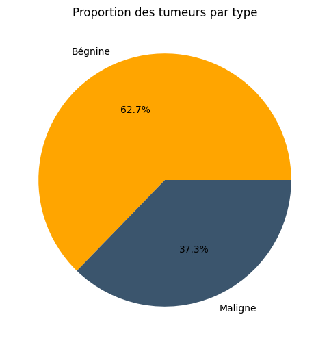

Via le diagramme circulaire ci-dessus, nous voyons que près de 62.7% des patients de notre jeu de données sont atteints d'une tumeurs de type Bégigne tandis que 37.3% sont atteint de tumeurs maligne.

Une tumeur est dite Bégnine si elle n'est pas conséreuse, il s'agit d'une masse qui ne se propage pas à d'autres parties du corps. À l'inverse, une tumeur maligne est conséreuse et elle envahit les tissus voisins.

Ici, on voit bien que la mojirité ne sont pas concéreuses.

## Question 2 : Tracer puis analyser l'histogramme du rayon (radius_mean)

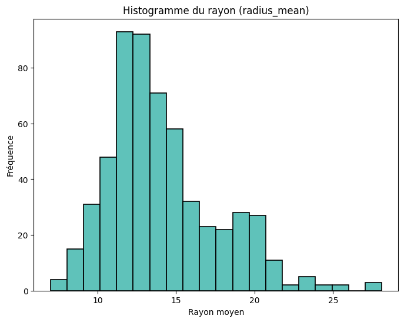

L'histogramme du rayon moyen présente une forme approchant une distribution gaussienne centrée autour de 12-13.

La majorité des tumeurs ont un rayon compris entre 10 et 15. Quant aux tumeurs dont le rayon est supérieur à 15, elles sont plus rares.

## Question 3 : Tracer, sur le même graphique, l'histogramme du rayon (radius_mean) en utilisant deux couleurs différentes pour différencier les tumeurs malignes (M) et des bénignes (B).

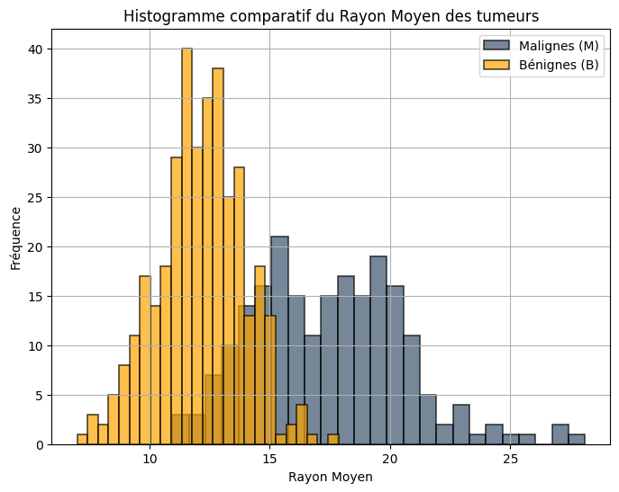

**Observation :**

> Je remarque que pour l'instant, dans deux histogrammes des tumeurs Bégnine (en or) et Maligne (en Bleu) ont tous l'air d'avoir l'allur d'une Gaussienne.

> De plus, une distinction ce fait autour d’un rayon de 15 : les tumeurs de rayon inférieur sont majoritairement bénignes, tandis que celles au-delà sont plus souvent malignes. Cela suggère une corrélation positive entre la taille du rayon et la probabilité qu’une tumeur soit maligne.

## Question 4 : Effectuer la même opération que précédemment pour les dix variables statistiques, en positionnant les histogrammes sur deux colonnes et cinq lignes.

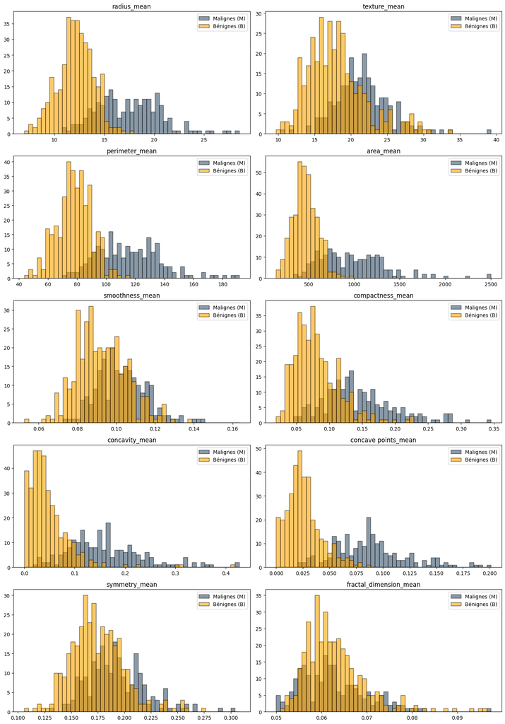

## Question 5 : A partir de la figure précédente et d'une analyse argumentée, en déduire quelles variables pourraient, a priori, être discriminantes pour déterminer l'état de la tumeur.

Au départ, je pensais qu’il fallait avant tout vérifier si les variables suivaient une distribution gaussienne. J’ai donc commencé par tracer les histogrammes dans cette idée, mais en avançant, je me suis rendu compte que ce critère n’était pas vraiment essentiel pour ce qu’on cherchait à faire. Après quelques recherches, j’ai compris que l’objectif principal n’était pas de modéliser une distribution, mais plutôt de savoir si certaines variables permettaient de différencier les deux types de tumeurs (malignes et bénignes). Ce qui comptait, c’était donc surtout de voir si les deux catégories se confondaient ou non sur les graphiques. J’ai ensuite observé les histogrammes à la recherche de variables où les courbes des deux groupes étaient bien séparées. J’ai retenu celles où la forme et l’emplacement des distributions montraient une différence assez nette entre les deux diagnostics.

J’estime donc que les variables suivantes sont correctes pour distinguer l’état des tumeurs :

> - radius_mean
> - perimeter_mean
> - area_mean
> - compactness_mean
> - concavity_mean
> - concave points_mean.

En observant les histogrammes, ces variables présentent un décalage assez clair entre les tumeurs bénignes et malignes. Les deux groupes ne se superposent pas trop, ce qui suggère qu’on peut s’en servir pour les différencier. Ce n’est pas forcément parce qu’elles suivent une forme particulière, mais plutôt parce qu’elles montrent visuellement une distinction entre les deux diagnostics, ce qui est utile pour un objectif de classification.

Toutes les autres sont donc à exclure car elles ne montrent pas de réelle séparation entre les tumeurs malignes et bénignes. Les distributions se recouvrent beaucoup, ce qui rend difficile la distinction entre les deux groupes.

## Question 6 : Tracer le nuage de points relatif à la texture en fonction du rayon, en utilisant deux couleurs différentes pour distinguer les tumeurs malignes (M) et bénignes (B). Analyser le nuage de point en termes de corrélation puis par rapport à l'objectif de classification des cas M ou B.

$$\text{Texture} = f(\text{rayon})$$

**Traduction** : on veut avoir en absisse le rayon et la texture en ordonnée. Car $~ y = f(x) ~$, dans notre cas, $~ x = \text{rayon} ~$ et $~ y = \text{Texture} ~$.

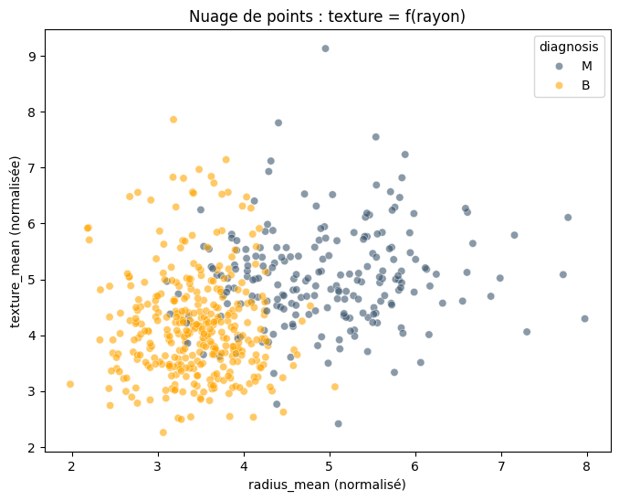

**Observations :**

> Cependant, même si l'on observe une légère tendance (les points ne sont pas complètement aléatoires), les deux types de tumeurs (M et B) restent partiellement mélangés.  
> Cela rend difficile une classification assez précise uniquement sur la base de ce nuage. On perçoit une structure, mais pas assez nette pour séparer les tumeurs malignes des bénignes de façon précise à l’œil nu.

> Mais si nous regardons que les points avec l'axe des ordonnée, nous ne décelons pas vraiement de lien. En effet, les il y a des tumeurs M et B à 3,5 et 6 sont mélangées.  
> Autrement dit, avec seulement la texture, je ne peux faire de classification correcte.

> Par contre, la rayon moyen semble être tout à fait pertinent. En effet, on distingue de petit cluster avec l'axe des abscisse. Entre 2 et 3,7 à peu près, on peut dire que la tumeur est Bégnine et entre 4.7 et 8 la tumeur et maligne.

> Cela montre à quelle point le rayon moyen est un indicateur performant dans notre analyse.

Pour se faire, **faisons parler les données avec les mathématiques !**

Calculons le coéfficient de corrélation de Monsieur Pearson et regardons s'il existe un lien entre ces deux variables

```
Le coéfficent de corrélation de Pearson est : 0.324 Soit environ : 32.38 %.

p_value inférieur à 0.05  --- Test Accépté ! ---
```

**Observations :**

> - Le coefficient de corrélation de Pearson est de 0.324 $~ \Longrightarrow ~$ ce qui indique une liaison modérée entre la texture et le rayon.
> - La p-value est inférieure à 0.05, donc le test est significatif $~ \Longrightarrow ~$ on peut rejeter l’hypothèse d’indépendance.

> Autrement dit, même si le lien n’est pas très fort, il est statistiquement réel. Cela confirme ce qu’on avait observé sur le nuage de points : une tendance existe, mais elle n’est pas assez marquée pour bien séparer les cas M et B à elle seule.

## Question 7 : Exploiter l'approche graphique précédente pour confirmer ou infirmer le caractère discriminant des variables isolées à la question 5.

Avant de me lancer dans tous les croisements possibles, j’ai d’abord essayé de réfléchir logiquement à ce qui pouvait être pertinent. J’ai commencé par éliminer les croisements entre variables qui sont dépendentes. Par exemple, `radius_mean` et `perimeter_mean` sont très liés géométriquement, donc leur combinaison ne m'apporterait probablement rien de plus qu'une seule des deux.

Ensuite, j’ai essayé de garder uniquement les croisements “potables”, c’est-à-dire ceux qui associent des variables de nature différente (par exemple une variable de **taille** avec une variable de **forme**, ou encore une variable **moyenne** avec une **valeur extrême** comme les `worst`). Mon objectif, à ce moment-là, c’était d’avoir des croisements qui auraient **une chance réelle de séparer visuellement les tumeurs malignes et bénignes**.

Après cette première sélection un peu “théorique”, je suis passé au concret : j’ai généré plein de graphiques, à la fois en 2D et en 3D. Puis j’ai regardé à chaque fois si les deux types de tumeurs (M et B) formaient des groupes séparés ou si les points restaient trop mélangés. J’ai conservé uniquement les graphes qui montraient une vraie distinction. Cela m'a pris énormément de temps car je devais à la fois observer, analyser et prendre une décision. Cela a donc nécessité une grande rigeur !

> Afin de visualiser les graphiques en 3D il est nécessaire d'être sur Jupyter Notebook ou VSCode (et probablement d'autre...). Ces graphiques utilisent la librairie Plotly. Je recommande d'utiliser VSCode pour pouvoir manipuler de manière fluide et efficace les graphiques. Si la bibliothèque n'est pas installer sur votre ordinateur, voici comment l'installer :
> - Avec Canda : $ conda install -c conda-forge plotly
> - avec Python (pip) : $ pip install plotly

Il me semble qu'il est néanmoint possible de run les graphiques en 3D sur Jupyter mais pour cela, il faut installer des packages... encore.

### Croisements 2D testés et observations

J’ai voulu croiser certaines variables deux à deux pour voir si, ensemble, elles permettaient de mieux distinguer les cas malins des cas bénins. Je n’étais pas certain du résultat, donc je me suis basé sur les visualisations pour juger. Voici quelques exemples que j’ai testés et qui m’ont paru intéressants visuellement :

- **`radius_mean` & `concave points_mean`**  
  → Je me suis dit que croiser une mesure de la taille moyenne des noyaux avec une mesure du nombre de creux dans leur forme pouvait être pertinent. Finalement, les deux types de tumeurs ont l’air de se séparer assez bien sur le graphique.
- **`area_mean` & `compactness_mean`**  
  → J’ai voulu tester si une combinaison entre la taille (l’aire) et une forme plus ou moins “serrée” du noyau pouvait aider à faire la différence. Les tumeurs malignes semblent regrouper des valeurs plus extrêmes sur ces deux axes.
- **`texture_mean` & `radius_worst`**  
  → Ce croisement m’a paru intéressant car il mélange une caractéristique visuelle (texture) et une mesure de taille extrême. Je ne savais pas trop à quoi m’attendre, mais le nuage de points montre que les malignes ont souvent à la fois une texture marquée et un grand rayon.
- **`area_worst` & `concave points_worst`**  
  → Là j’ai testé les valeurs les plus extrêmes possibles sur deux axes différents : taille et forme. L’idée était de voir si au moins une cellule très grande et très irrégulière suffisait à faire ressortir les cas malins, ce qui semble être le cas.

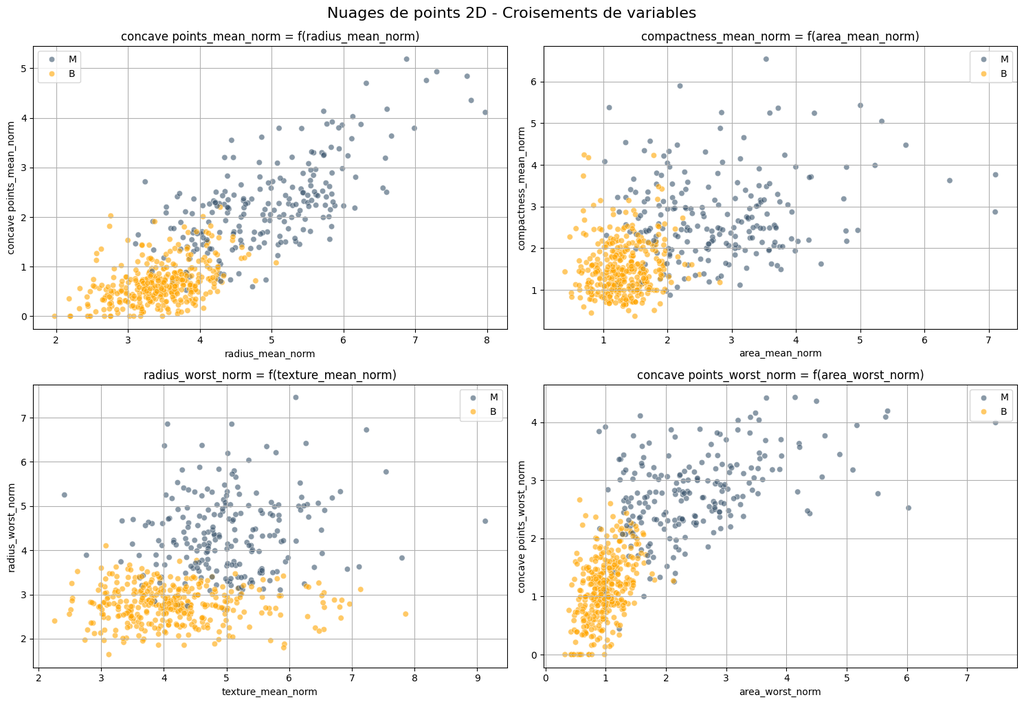

### Croisements de variables en 3D (visualisation interactive)

Après avoir testé des visualisations en 2D, j’ai voulu voir si passer en 3D permettrait de mieux distinguer les tumeurs bénignes et malignes.  
Je me suis donc appuyé sur certains croisements que j’avais déjà trouvés intéressants en 2D, et j’ai essayé de les combiner par trois.  
L’idée, c’était de mélanger des variables qui mesurent des choses différentes (forme, taille, texture…), en espérant que ça fasse ressortir deux groupes de points bien distincts.

Voici quelques combinaisons testées :

- **`radius_mean` / `concavity_mean` / `concave points_mean`**  
  → Ces trois variables tournent autour de la taille et de l’irrégularité du contour. Je ne savais pas si c’était trop redondant ou pas, mais en 3D, on voit que les cas malins ont tendance à avoir des valeurs hautes sur les trois axes, ce qui crée un petit regroupement.
- **`radius_mean` / `concave points_mean` / `radius_se`**  
  → Ici, j’ai voulu mélanger la taille moyenne du noyau, son irrégularité, et l’écart-type des tailles. Ça donne une idée à la fois de la forme générale et de la dispersion des tailles, ce qui m’a semblé intéressant pour repérer des tumeurs malignes plus hétérogènes.
- **`area_mean` / `concave points_worst` / `compactness_se`**  
  → Ce croisement combine la taille moyenne, un cas extrême d’irrégularité, et la variabilité de compacité. Ça m’a paru utile pour aller chercher des tumeurs aux comportements plus “atypiques”, qu’on ne verrait pas forcément avec les valeurs moyennes seules.

Tous ces croisements ont été visualisés en 3D avec des graphes interactifs. J’ai cherché ceux où on pouvait voir apparaître deux “amas” ou au moins une tendance à séparer les points M et B. Certains fonctionnent mieux que d’autres, mais dans l’ensemble, la 3D apporte un regard complémentaire aux 2D.

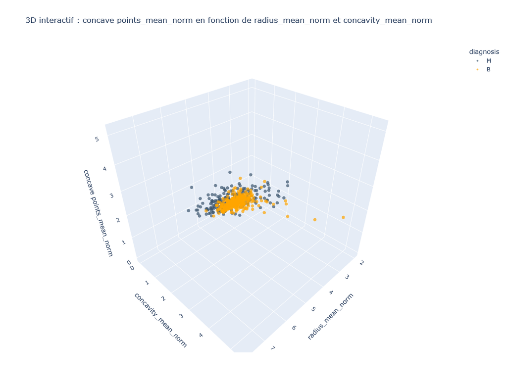

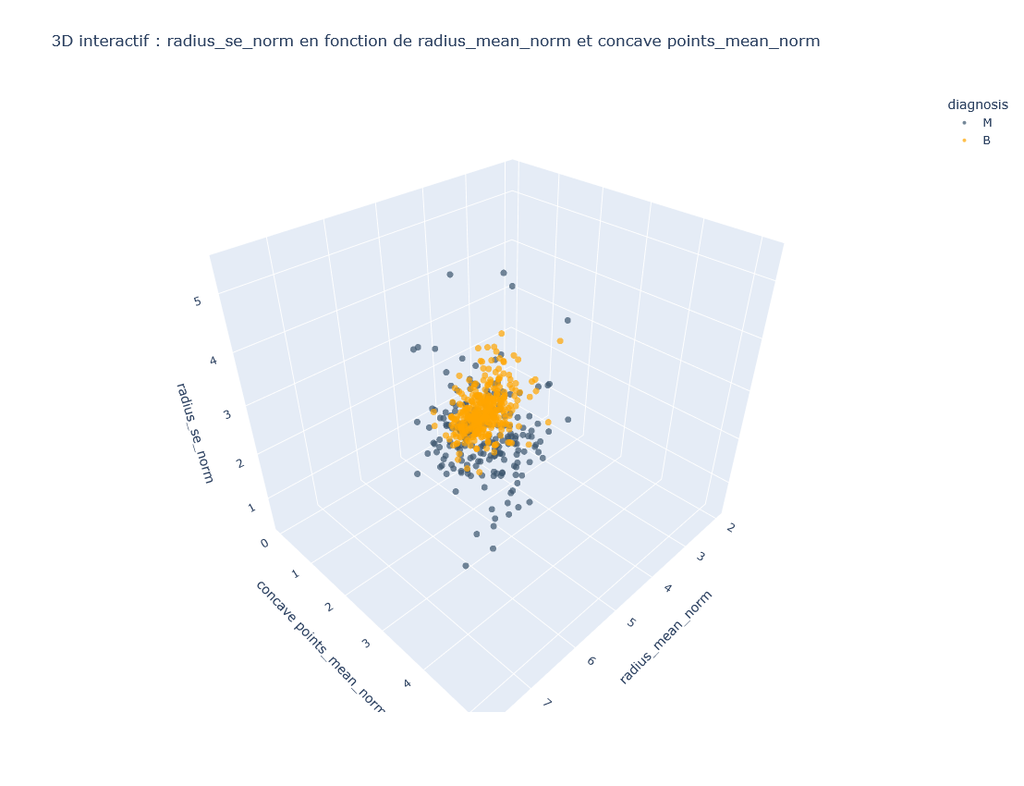

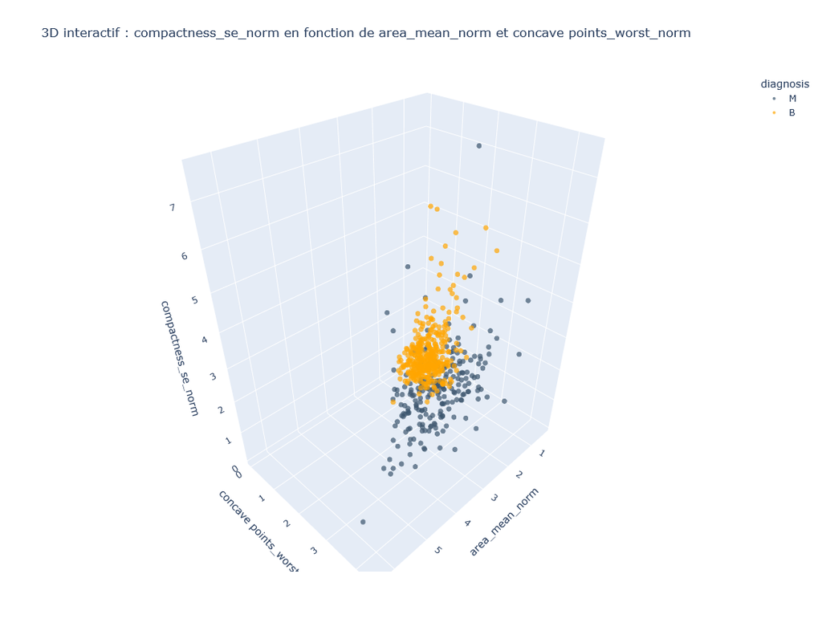

### Démarche suivie

Avant de me lancer dans tous les croisements possibles, j’ai essayé de raisonner logiquement pour ne pas tester des combinaisons inutiles. Par exemple, `radius_mean` et `perimeter_mean` sont très liés géométriquement, donc les combiner n’apporte pas forcément plus d'information que l’un des deux.

Ensuite, j’ai sélectionné uniquement les croisements qui associaient :

- une variable de **taille** avec une variable de **forme**
- ou une variable **moyenne** avec une variable **extrême** (comme les `worst`).

Mon objectif était de trouver des croisements qui ont une **chance réelle de séparer visuellement** les deux types de tumeurs.

Enfin, j’ai généré plusieurs nuages de points (2D puis 3D) et j’ai observé si les cas M et B formaient des groupes séparés ou non. J’ai gardé uniquement ceux qui montraient une vraie distinction.

### Croisements 2D testés

Voici quelques croisements 2D que j’ai testés, avec une brève explication et une estimation de leur efficacité visuelle :

| Croisement 2D | Idée du test | Résultat |
| --- | --- | --- |
| `radius_mean` & `concave points_mean` | Taille moyenne + forme du contour | ** Bonne séparation visuelle |
| `area_mean` & `compactness_mean` | Aire + forme plus ou moins “serrée” | ** Les cas M ressortent bien |
| `texture_mean` & `radius_worst` | Texture + taille extrême | ** Cas M souvent avec texture forte + grand rayon |
| `area_worst` & `concave points_worst` | Taille extrême + irrégularité | *** Très bonne séparation nette |

Tous ces croisements nous ont permis d'observer qu’en combinant **taille et forme**, on distingue généralement mieux les tumeurs malignes des bénignes.

### Représentations graphiques en 3D

Pour aller plus loin, j’ai utilisé des visualisations **3D interactives** avec la librairie `plotly`. J’ai repris certaines des variables intéressantes en 2D, mais cette fois combinées par **3**.

Voici les triplets que j’ai testés, avec les observations faites :

[output not shown]

Ces représentations 3D m'ont permis de **confirmer certains résultats vus en 2D**, mais surtout d’**isoler des cas plus hétérogènes** qu’on ne voyait pas forcément avant.

### Conclusion

Grâce à l’approche graphique en 2D et 3D, j’ai pu confirmer que plusieurs variables étaient bien discriminantes, notamment :

- `radius_mean`
- `area_mean`
- `concave points_mean` et `concave points_worst`
- `compactness_mean` et `compactness_se`
- `texture_mean`

Ce sont souvent des combinaisons **entre la taille, la forme, et l’irrégularité** qui donnent les meilleures séparations visuelles entre tumeurs malignes (M) et bénignes (B).

En résumé :

- ** Les croisements 2D sont déjà très utiles
- ** Les visualisations 3D permettent d'aller plus loin, notamment pour repérer des cas atypiques
- *** Les variables extrêmes (worst, se) combinées à des moyennes donnent souvent de très bons résultats

## Question 8 : Si possible, en considérant certaines variables statistiques pertinentes, proposer et mettre en oeuvre une méthode quantitative permettant d'opérer la classification des états M ou B.

## Méthode utilisée : K-Means + ACP (Analyse en Composantes Principales)

Dans cette partie, j'ai essayé une première méthode de classification automatique pour distinguer les tumeurs malignes (M) des bénignes (B). J’ai choisi d’utiliser l’algorithme **K-Means**, combiné avec une **réduction de dimension via l’ACP** pour faciliter la visualisation.

### K-Means : principe

K-Means est un algorithme de **clustering non supervisé**. Il ne connaît pas les vraies classes (ici M ou B), mais il regroupe les observations en `k` groupes (ou clusters) en minimisant une **distance intra-cluster**.

L'objectif est de minimiser la somme des distances au carré entre chaque point et le centre de son cluster :

$$ \text{Inertia} = \sum_{i=1}^{n} \| x_i - \mu_{c(i)} \|^2 $$

où :

- $ x_i $ est une observation,
- $ \mu_{c(i)} $ est le centroïde du cluster auquel appartient $ x_i $ (le centre de gravité d'après ce que nous avons compris),
- la norme $ \| \cdot \|^2 $ est la distance euclidienne au carré.

Ici, nous vons fixé **k = 2** car on veut séparer les tumeurs en deux groupes : M et B.

### ACP : pourquoi ?

Comme il y a beaucoup de variables (30 au total), nous avons d’abord appliqué une **Analyse en Composantes Principales (ACP)** pour réduire la dimension à **2 axes principaux**, tout en conservant l'information essentielle.

Cette transformation permet de projeter les données dans un plan 2D tout en gardant le plus de variance possible. Cela aide K-Means à mieux travailler et permet de visualiser les résultats.

### Évaluation : silhouette score

Pour mesurer la qualité du clustering, j’ai utilisé le **silhouette score** :

$$ s = \frac{b - a}{\max(a, b)} $$

où :

- $ a $ est la distance moyenne entre un point et les autres points du même cluster,
- $ b $ est la distance moyenne entre ce point et les points du cluster le plus proche.

Le score varie entre -1 et 1 :

- proche de 1 → bonne séparation,
- proche de 0 → clusters proches ou superposés,
- proche de -1 → mauvais regroupement.

|  | radius_mean | texture_mean | perimeter_mean | area_mean | smoothness_mean | compactness_mean | concavity_mean | concave points_mean | symmetry_mean | fractal_dimension_mean | ... | texture_worst | perimeter_worst | area_worst | smoothness_worst | compactness_worst | concavity_worst | concave points_worst | symmetry_worst | fractal_dimension_worst | diagnosis_encoded |
| --- | --- | --- | --- | --- | --- | --- | --- | --- | --- | --- | --- | --- | --- | --- | --- | --- | --- | --- | --- | --- | --- |
| 0 | 17.99 | 10.38 | 122.80 | 1001.0 | 0.11840 | 0.27760 | 0.30010 | 0.14710 | 0.2419 | 0.07871 | ... | 17.33 | 184.60 | 2019.0 | 0.16220 | 0.66560 | 0.7119 | 0.2654 | 0.4601 | 0.11890 | 1 |
| 1 | 20.57 | 17.77 | 132.90 | 1326.0 | 0.08474 | 0.07864 | 0.08690 | 0.07017 | 0.1812 | 0.05667 | ... | 23.41 | 158.80 | 1956.0 | 0.12380 | 0.18660 | 0.2416 | 0.1860 | 0.2750 | 0.08902 | 1 |
| 2 | 19.69 | 21.25 | 130.00 | 1203.0 | 0.10960 | 0.15990 | 0.19740 | 0.12790 | 0.2069 | 0.05999 | ... | 25.53 | 152.50 | 1709.0 | 0.14440 | 0.42450 | 0.4504 | 0.2430 | 0.3613 | 0.08758 | 1 |
| 3 | 11.42 | 20.38 | 77.58 | 386.1 | 0.14250 | 0.28390 | 0.24140 | 0.10520 | 0.2597 | 0.09744 | ... | 26.50 | 98.87 | 567.7 | 0.20980 | 0.86630 | 0.6869 | 0.2575 | 0.6638 | 0.17300 | 1 |
| 4 | 20.29 | 14.34 | 135.10 | 1297.0 | 0.10030 | 0.13280 | 0.19800 | 0.10430 | 0.1809 | 0.05883 | ... | 16.67 | 152.20 | 1575.0 | 0.13740 | 0.20500 | 0.4000 | 0.1625 | 0.2364 | 0.07678 | 1 |
| ... | ... | ... | ... | ... | ... | ... | ... | ... | ... | ... | ... | ... | ... | ... | ... | ... | ... | ... | ... | ... | ... |
| 564 | 21.56 | 22.39 | 142.00 | 1479.0 | 0.11100 | 0.11590 | 0.24390 | 0.13890 | 0.1726 | 0.05623 | ... | 26.40 | 166.10 | 2027.0 | 0.14100 | 0.21130 | 0.4107 | 0.2216 | 0.2060 | 0.07115 | 1 |
| 565 | 20.13 | 28.25 | 131.20 | 1261.0 | 0.09780 | 0.10340 | 0.14400 | 0.09791 | 0.1752 | 0.05533 | ... | 38.25 | 155.00 | 1731.0 | 0.11660 | 0.19220 | 0.3215 | 0.1628 | 0.2572 | 0.06637 | 1 |
| 566 | 16.60 | 28.08 | 108.30 | 858.1 | 0.08455 | 0.10230 | 0.09251 | 0.05302 | 0.1590 | 0.05648 | ... | 34.12 | 126.70 | 1124.0 | 0.11390 | 0.30940 | 0.3403 | 0.1418 | 0.2218 | 0.07820 | 1 |
| 567 | 20.60 | 29.33 | 140.10 | 1265.0 | 0.11780 | 0.27700 | 0.35140 | 0.15200 | 0.2397 | 0.07016 | ... | 39.42 | 184.60 | 1821.0 | 0.16500 | 0.86810 | 0.9387 | 0.2650 | 0.4087 | 0.12400 | 1 |
| 568 | 7.76 | 24.54 | 47.92 | 181.0 | 0.05263 | 0.04362 | 0.00000 | 0.00000 | 0.1587 | 0.05884 | ... | 30.37 | 59.16 | 268.6 | 0.08996 | 0.06444 | 0.0000 | 0.0000 | 0.2871 | 0.07039 | 0 |

569 rows × 31 columns

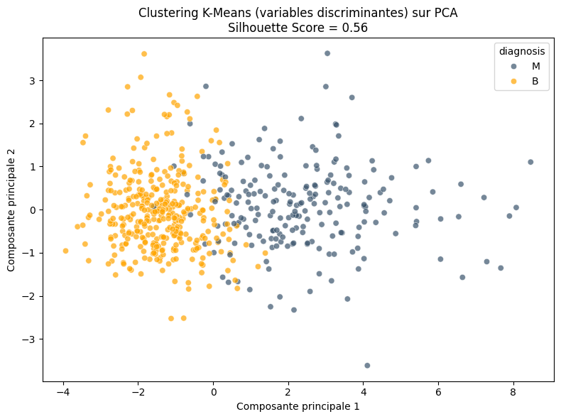

## Résultats et interprétation

Après l’application du K-Means sur les deux premières composantes principales, on observe deux regroupements plutôt bien séparés. Le **silhouette score est de 0.56**, ce qui est **modérément satisfaisant** : la séparation n’est pas parfaite, mais il y a **quand même une structure identifiable** dans les données.

Visuellement, on voit que les tumeurs malignes (M) et bénignes (B) ne se mélangent pas trop, ce qui confirme que les variables choisies contiennent **de l’information discriminante**.

Cela montre que, même sans supervision (sans connaître les classes), **une méthode simple comme K-Means combinée à une réduction de dimension** peut déjà capturer une séparation non aléatoire.

## Mise en évidence de liaisons entre les variables

### Question 1 : Pour chaque combinaison possible dont on calculera en premier lieu le nombre total, rechercher l'existence de corrélations entre les variables statistiques de la liste précédente.

```
À partir des 5 grandeurs, nous avons : 15 variables.
Nombre de Combinaisons par paires (couples) : 105 variables.
Nombre de Combinaisons par triplets : 455 variables.
```

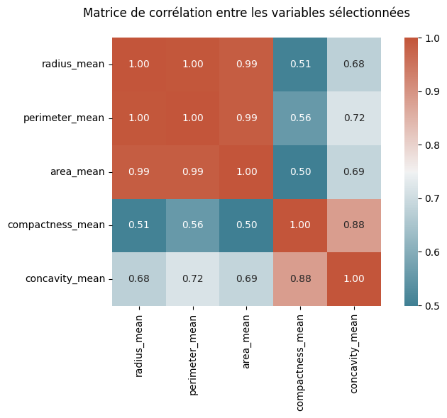

### Analyse de la matrice de corrélation (variables `mean`)

La matrice ci-dessus présente les coefficients de corrélation de Pearson entre les variables `mean` des cinq grandeurs étudiées : `radius`, `perimeter`, `area`, `compactness`, et `concavity`.

#### 1. Corrélations très fortes entre variables de taille

- `radius_mean` ~ `perimeter_mean` → corrélation = **1.00**
- `radius_mean` ~ `area_mean` → **0.99**
- `area_mean` ~ `perimeter_mean` → **0.99**

Ces trois variables mesurent toutes la **taille globale** du noyau de la tumeur, mais à travers des perspectives géométriques différentes. Leur très forte corrélation indique qu'elles sont quasiment redondantes.

**Implication** : il est déconseillé de les utiliser ensemble dans un modèle de classification car cela introduirait une forte redondance et possiblement de la multicolinéarité.

#### 2. Corrélations fortes entre variables de forme

- `compactness_mean` ~ `concavity_mean` → corrélation = **0.88**

Ces deux variables décrivent des aspects similaires de la **forme du contour** de la tumeur. Une tumeur très concave est généralement aussi peu compacte. Leur forte corrélation est donc logique.

#### 3. Corrélations intermédiaires entre taille et forme

- `radius_mean` ~ `concavity_mean` $\Longrightarrow$ **0.68**
- `perimeter_mean` ~ `concavity_mean` $\Longrightarrow$ **0.72**
- `area_mean` ~ `concavity_mean` $\Longrightarrow$ **0.69**
- `radius_mean` ~ `compactness_mean` $\Longrightarrow$ **0.51**

Ces corrélations indiquent que les tumeurs de grande taille ont souvent des contours plus creusés ou moins compacts. Cela peut être une caractéristique importante pour différencier les tumeurs bénignes et malignes.

### Conclusion

- Les variables liées à la **taille** (`radius`, `perimeter`, `area`) sont très fortement corrélées entre elles. Il est préférable de n’en garder qu’une seule dans un modèle.
- De même, `compactness_mean` et `concavity_mean` étant aussi très corrélées, on évitera de les utiliser ensemble.

Pour une bonne **diversité de l’information**, il est pertinent de croiser des variables de taille avec des variables de forme, tout en surveillant les corrélations excessives.

### Question 2 : En cas d'une probable corrélation, établir un ajustement linéaire optimal au sens des moindres carrés.

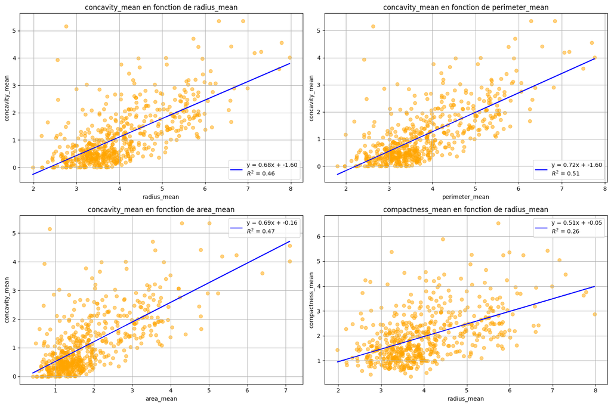

### Résultats de la régression linéaire simple

Ce tableau synthétise les résultats des régressions linéaires effectuées sur les couples de variables montrant une corrélation intermédiaire entre taille et forme.

| Variable X | Variable Y | R² | Interprétation rapide |
| --- | --- | --- | --- |
| `radius_mean` | `concavity_mean` | 0.46 | Relation positive modérée : plus le rayon augmente, plus la concavité augmente aussi. |
| `perimeter_mean` | `concavity_mean` | 0.51 | Meilleure corrélation que le rayon : le périmètre est plus étroitement lié à la concavité. |
| `area_mean` | `concavity_mean` | 0.47 | Corrélation également modérée : les tumeurs étendues sont souvent plus concaves. |
| `radius_mean` | `compactness_mean` | 0.26 | Corrélation faible : la taille du noyau n'explique pas bien la compacité. |

**Remarque :**

- Le R² (coefficient de détermination) donne une idée de la qualité d’ajustement de la droite : plus il est proche de 1, mieux la droite de régression explique la variabilité des données.

Ces résultats confirment l’existence de **liens structurels** entre certaines grandeurs géométriques des tumeurs (taille, forme, irrégularité), même si toutes les relations ne sont pas parfaitement linéaires.

**À noter :**

- Le lien entre `area_mean` et `concavity_mean` donne pratiquement la même qualité de prédiction (R² = 0.47) que celui entre `radius_mean` et `concavity_mean` (R² = 0.46).

Cela s’explique par le fait que `radius_mean` et `area_mean` sont eux-mêmes très fortement corrélés (R ≈ 0.99). En pratique, **ils traduisent une information similaire sur la taille du noyau**.

### Introduction à la régression linéaire multiple

Dans cette section, nous étudions une **relation linéaire multiple** entre plusieurs variables statistiques issues du jeu de données médical. L’objectif est de modéliser la variable `concavity_mean` (mesure de la courbure dans les contours des tumeurs) en fonction de deux autres variables : `radius_mean` (taille moyenne du noyau) et `compactness_mean` (lissage ou densité du contour).

La régression linéaire multiple cherche à ajuster un **plan** dans un espace 3D, à partir d’un modèle de la forme :

$$ \text{concavity\_mean} = \beta_1 \cdot \text{radius\_mean} + \beta_2 \cdot \text{compactness\_mean} + \epsilon $$

où :

- $\beta_1$ et $\beta_2$ sont les coefficients associés à chaque variable explicative,
- $\epsilon$ est l’erreur aléatoire.

Un **prétraitement par normalisation** a été appliqué sur les variables afin de rendre les échelles comparables. Un graphique interactif en 3D permet ensuite de visualiser à la fois les données et le plan ajusté.

**GRAPHIQUE 3D INTÉRACTIF $\Longrightarrow$ librairie PLOTLY $\wedge$ (VSCode $\vee$ Notebook) !**

```
Modèle de régression linéaire multiple :
concavity_mean = 0.3089 * radius_mean + 0.7268 * compactness_mean + -1.5604
R² : 0.851
```

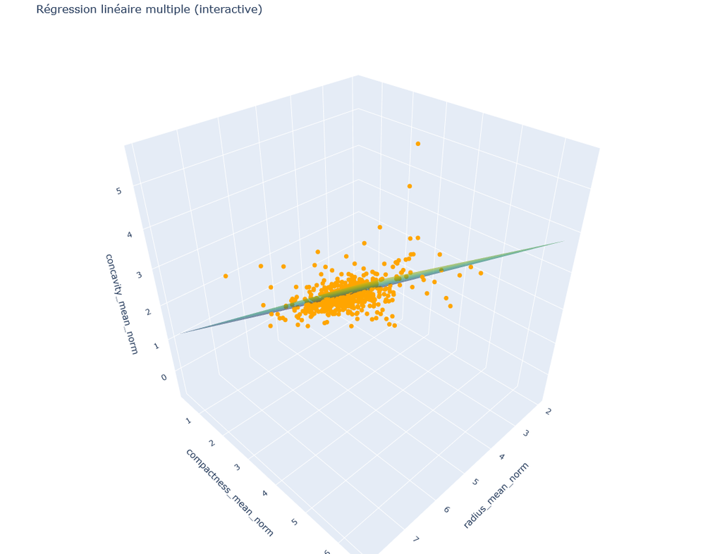

### Observations et conclusion

Le modèle obtenu est le suivant :

$$ \text{concavity\_mean} = 0.3089 \cdot \text{radius\_mean} + 0.7268 \cdot \text{compactness\_mean} - 1.5604 $$

avec un coefficient de détermination $R^2 = 0.851$. Ce score est très élevé, ce qui signifie que **plus de 85 % de la variabilité de `concavity_mean`** est expliquée par la combinaison linéaire de `radius_mean` et `compactness_mean`.

Cela montre que ces deux variables (**l'une liée à la taille**, l'autre **à la forme du contour**) sont fortement informatives pour prédire la concavité moyenne d'une tumeur. De plus, le modèle est cohérent visuellement (plan bien ajusté) et numériquement (forte explicabilité).

Enfin, ce bon résultat valide le choix de ces trois variables comme **bon triplet complémentaire** : elles agissent sur des dimensions différentes de la tumeur et permettent, ensemble, une modélisation efficace et interprétable. Ce type d’analyse est particulièrement pertinent dans un contexte de classification ou de diagnostic médical.

## BONUS : Prédiction avec régréssion logistique

### Préparation des données pour la classification

Avant de mettre en place une méthode de classification (comme la régression logistique ou une autre), j’ai commencé par séparer mes données en deux parties : un **jeu d’apprentissage** et un **jeu de test**.

Cela permet d’entraîner le modèle sur une partie des données, puis de voir s’il fonctionne bien sur des données qu’il n’a jamais vues. Pour faire ça, j’utilise la fonction `train_test_split`, qui est une étape standard en machine learning supervisé.

> Ce n’est pas réservé à un seul modèle : on l’utilise aussi bien pour la régression logistique que pour d’autres méthodes comme KNN, les arbres de décision, ou encore SVM (que je ne connais pas du tout :) )

L’objectif ici est de tester différentes méthodes de manière équitable, en comparant leurs performances sur des données de test identiques.

Alors tout d'abord, commencons par une petite partie d'explication qui servira d'une part à moi même car j'apprend cela en direct et d'autre part à M. HÉBERT (ou M. LAVAL s'il recorrige ma copie) qui peut être ne connait pas la méthode. Alors qu'est-ce qui se passe dans `train_test_split` ?

[figure not shown]

Bon, avant d’aller trop loin dans l’analyse du modèle, je me suis posé une question toute simple : comment savoir si un modèle est “bon” ? Et surtout, comment l’évaluer proprement ? Apparemment, dans le monde du Machine Learning, une pratique courante est de séparer nos données. Une partie sert à entraîner le modèle (on appelle ça le train set), et l’autre à le tester (le test set).

C’est là qu’intervient la fonction `train_test_split` de `sklearn`. Elle permet de découper nos données très facilement. Et comme on peut le voir sur l’image à gauche, on fournit à la fonction nos variables explicatives (X) et notre variable cible (y), et elle nous renvoie quatre morceaux : `X_train`, `X_test`, `y_train`, et `y_test`.

En fait, c’est comme si on réservait une partie des données de côté pour ne pas tricher, afin de voir si notre modèle est capable de prédire correctement des données qu’il n’a jamais vues. Franchement, je ne savais pas que c’était aussi important, mais maintenant je vois pourquoi on fait ça. On évite ainsi les fameux pièges comme le sur-apprentissage (overfitting) ou l'inverse (underfitting).

### Sur-apprentissage vs Sous-apprentissage

**Quand j’ai commencé à entraîner mes modèles, j’ai découvert deux notions importantes à comprendre :**

#### 1. Sur-apprentissage (Overfitting)

C’est quand un modèle apprend *trop bien* les données d’entraînement. Il ne se contente pas de comprendre les grandes tendances, il apprend aussi tous les petits détails, même ceux qui n’ont pas vraiment de sens (comme du bruit ou des cas exceptionnels).

Du coup, il fonctionne parfaitement sur les données qu’il connaît, mais quand on lui montre de nouvelles données, il se trompe facilement. C’est un peu comme un élève qui apprend par cœur toutes les réponses à un exercice, mais se retrouve perdu quand la question change un peu.

**Symptômes :**  
- Très bonne performance sur les données d’entraînement (`X_train`)  
- Mauvaise performance sur les données de test (`X_test`)

#### 2. Sous-apprentissage (Underfitting)

À l’inverse, le sous-apprentissage, c’est quand le modèle n’arrive même pas à bien apprendre les données d’entraînement. Il est trop simple ou mal paramétré, donc il ne comprend pas les relations dans les données, même les plus évidentes.

C’est comme si on donnait un modèle trop basique pour résoudre un problème un peu plus complexe — il ne fait pas de bonnes prédictions, que ce soit en apprentissage ou en test.

**Symptômes :**  
- Mauvaise performance sur **tout**, même les données d’entraînement  
- Aucun signe qu’il s’améliore, même après plusieurs essais

#### Mon avis :

Avant je ne savais pas que c’était possible d’*apprendre “trop” bien*... mais maintenant je comprends que le plus important, c’est que le modèle soit capable de généraliser, c’est-à-dire de bien se débrouiller avec des données qu’il n’a jamais vues.

C’est aussi pour ça qu’on utilise `train_test_split` : pour détecter ce genre de situation, et éviter de se faire piéger par un modèle trop “parfait” qui en fait ne sert à rien en pratique.

Source Image : `https://datascientest.com/`

Essayons cela tout d'abord avec le rayon moyen et la concavité moyenne :

```
Taux de réussite : 90.35 %
```

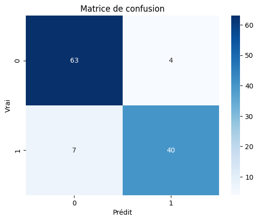

### Résultats du modèle – Analyse des performances

#### 1. Accuracy (taux de réussite)

Le modèle atteint un taux de réussite de **90.35 %**, ce qui est plutôt satisfaisant au premier abord.  
Mais attention : ce chiffre ne dit pas *où* le modèle se trompe. Il faut donc aller plus loin avec la matrice de confusion.

#### 2. Matrice de confusion

|  | Prédit B (0) | Prédit M (1) |
| --- | --- | --- |
| **Vrai B (0)** | 63 | 4 |
| **Vrai M (1)** | 7 | 40 |

- **63** vrais bénins → bien classés
- **40** vrais malins → bien classés
- **7** malins mal classés comme bénins → **faux négatifs**
- **4** bénins mal classés comme malins → **faux positifs**

#### Interprétation

- Le modèle **repère très bien les cas bénins** (seulement 4 erreurs).
- Il **manque un peu de sensibilité sur les cas malins**, avec 7 faux négatifs → c’est embêtant car ça veut dire que certaines tumeurs cancéreuses ne sont pas détectées.
- En pratique, il vaudrait peut-être mieux **réduire ces faux négatifs**, même si ça augmente un peu les faux positifs.

#### En résumé

Le modèle fonctionne globalement bien (**90 % de réussite**), mais si on devait l’améliorer, je chercherais à :

- Réduire le nombre de faux négatifs (priorité)
- Peut-être revoir les variables utilisées ou tester un autre modèle

### Classification sur les paires de variables sélectionner à la question 5)

#### Commencons par regarder quelle croisement serait pertinent

Pour cela procédons à peu de machine learning. Ce que je veux faire, c'est parmis les variables que j'ai sélectionné faire un produit cartésient entre toutes les possibilités possibles. Bon je ne fait pas n'importe quelle croisement, par exemple j'ai exlu les croisement de variables possédant la même base (ex : raduis_mean et radius_worst) et aussi croisement de variables dépendante (ex : raidus_mean et permietre_mean).

Faisons le produit cartésien avec une combinaison par n-uplet avec $n \in [2,4] ~~ \text{un entier}$ :

[output not shown]

[figure not shown]

#### Classification par 2-uplets

À présent, une fois les tuples de variables crées. Utilisons la méthode de régression logistique pour classifier les tumeurs Maligne et Bégnine.  
Une fois la régression faites, nous calculerons le taux de précison de chaque variable, sélectionnerons que les tuples où le taux sera supérieur à 0.85 et prendrons le TOP10.

```
À partir des 5 grandeurs, nous avons : 21 variables.
Nombre de Combinaisons par paires (couples) : 210 variables.
Nombre de Combinaisons par triplets : 1330 variables.
Nombre de Combinaisons par 4-uplets : 5985 variables.
```

|  | Var_1 | Var_2 | Accuracy |
| --- | --- | --- | --- |
| 69 | area_worst | texture_worst | 95.61 |
| 31 | radius_worst | texture_mean | 95.61 |
| 27 | radius_worst | concavity_worst | 94.74 |
| 68 | area_worst | texture_se | 94.74 |
| 60 | area_worst | compactness_worst | 94.74 |
| 67 | area_worst | texture_mean | 94.74 |
| 2 | radius_mean | area_worst | 94.74 |
| 33 | radius_worst | texture_worst | 94.74 |
| 24 | radius_worst | compactness_worst | 93.86 |
| 32 | radius_worst | texture_se | 93.86 |

### Choix final des couples de variables

Parmi toutes les combinaisons testées, j’ai choisi de retenir les deux suivantes :

- `radius_worst` et `texture_mean` (taux de réussite : **95.61 %**)
- `area_worst` et `compactness_worst` (taux de réussite : **94.74 %**)

Ces paires me paraissent intéressantes car elles associent des variables assez différentes : par exemple, l’une décrit la taille ou l’étendue d’une tumeur, l’autre plutôt sa forme ou son aspect.  
Cela permet probablement de mieux séparer les deux types de tumeurs. De plus, ce sont des variables qu’on avait déjà repérées comme assez discriminantes plus tôt dans l’étude, donc leur bon score n’est pas surprenant.

On pourrait penser que `area_worst` et `texture_worst` est une bonne paire car elle donne un excellent taux de réussite. Mais en réalité, cette combinaison repose sur deux variables extrêmes, dont l'une (`area_worst`) est déjà fortement liée à `radius_worst`, qui est utilisé dans la meilleure combinaison. Étant donné que `area` est fortement corrélée au `radius` (puisque l’aire est liée au rayon), cela rend le second duo un peu redondant avec le premier. J’ai donc préféré retenir `area_worst` avec une variable de forme (`compactness_worst`) dans la deuxième combinaison, car elle apporte une information différente et plus complémentaire.

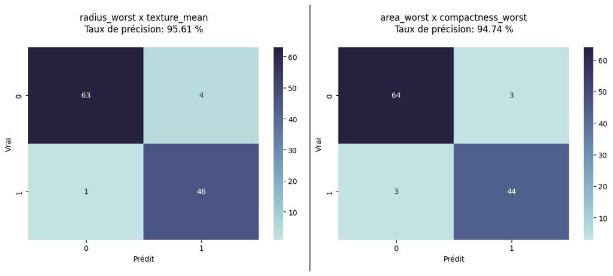

#### Observations sur les deux couples sélectionnés

| Couple de variables | Taux de précision | Vrais positifs (1 bien prédit) | Faux négatifs (1 prédit 0) | Faux positifs (0 prédit 1) |
| --- | --- | --- | --- | --- |
| `radius_worst` × `texture_mean` | **95.61 %** | 46 | 1 | 4 |
| `area_worst` × `compactness_worst` | **94.74 %** | 44 | 3 | 3 |

- Le premier couple affiche une meilleure précision globale, avec **moins de faux négatifs**, ce qui est important car cela signifie qu'on rate moins de tumeurs malignes.
- Le second couple est aussi très performant, avec un **équilibre** entre faux positifs et faux négatifs.

#### Conclusion

Les deux couples choisis permettent une bonne séparation des tumeurs malignes et bénignes.  
On remarque toutefois que le couple `radius_worst` × `texture_mean` donne les meilleurs résultats,  
notamment grâce à un **faux négatif unique**, ce qui en fait un choix **plus sécurisé médicalement**.

#### Classification par 3-uplets

Appliquons le même raisonnement pour cette fois ci des 3-uplets

|  | Var_1 | Var_2 | Var_3 | Accuracy |
| --- | --- | --- | --- | --- |
| 31 | radius_mean | area_worst | concave points_se | 95.61 |
| 30 | radius_mean | area_worst | concave points_mean | 95.61 |
| 27 | radius_mean | area_worst | concavity_mean | 95.61 |
| 32 | radius_mean | area_worst | concave points_worst | 95.61 |
| 24 | radius_mean | area_worst | compactness_mean | 95.61 |
| 25 | radius_mean | area_worst | compactness_se | 95.61 |
| 28 | radius_mean | area_worst | concavity_se | 95.61 |
| 225 | radius_worst | concavity_worst | texture_worst | 95.61 |
| 199 | radius_worst | compactness_worst | concavity_mean | 95.61 |
| 35 | radius_mean | area_worst | texture_worst | 94.74 |
| 388 | area_worst | concave points_mean | texture_mean | 94.74 |
| 395 | area_worst | concave points_worst | texture_se | 94.74 |
| 389 | area_worst | concave points_mean | texture_se | 94.74 |
| 391 | area_worst | concave points_se | texture_mean | 94.74 |
| 34 | radius_mean | area_worst | texture_se | 94.74 |
| 396 | area_worst | concave points_worst | texture_worst | 94.74 |
| 33 | radius_mean | area_worst | texture_mean | 94.74 |
| 358 | area_worst | compactness_se | texture_mean | 94.74 |
| 361 | area_worst | compactness_worst | concavity_mean | 94.74 |
| 352 | area_worst | compactness_se | concavity_mean | 94.74 |

### Sélection de triplets de variables (3D)

Parmi l’ensemble des triplets testés, certaines combinaisons atteignent un **haut niveau de précision tout en gardant des variables complémentaires** (c’est-à-dire sans redondance sur une même base comme `radius_mean` et `radius_se`).

Voici trois triplets retenus pour leur équilibre entre performance et diversité :

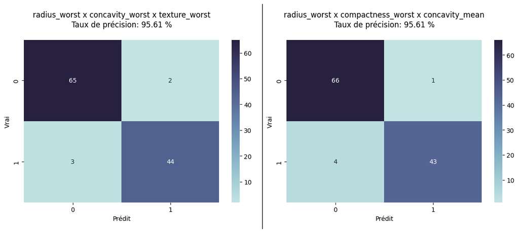

|  | Var_1 | Var_2 | Var_3 | Var_4 | Accuracy |
| --- | --- | --- | --- | --- | --- |
| 351 | radius_worst | concavity_worst | texture_worst | fractal_dimension_mean | 95.61 |
| 353 | radius_worst | concavity_worst | texture_worst | fractal_dimension_worst | 95.61 |
| 352 | radius_worst | concavity_worst | texture_worst | fractal_dimension_se | 95.61 |
| 273 | radius_worst | compactness_worst | concavity_mean | fractal_dimension_mean | 95.61 |
| 274 | radius_worst | compactness_worst | concavity_mean | fractal_dimension_se | 95.61 |
| 275 | radius_worst | compactness_worst | concavity_mean | fractal_dimension_worst | 95.61 |
| 794 | area_worst | concavity_mean | concave points_worst | fractal_dimension_worst | 95.61 |
| 289 | radius_worst | compactness_worst | concave points_worst | fractal_dimension_se | 94.74 |
| 290 | radius_worst | compactness_worst | concave points_worst | fractal_dimension_worst | 94.74 |
| 807 | area_worst | concavity_se | concave points_se | fractal_dimension_mean | 94.74 |

### Sélection du meilleur 4-uplet

```
["radius_worst", "concavity_worst", "texture_worst", "fractal_dimension_worst"]
```

Pourquoi ce choix ?

- radius_worst → indique la **taille maximale du noyau**
- concavity_worst → mesure la **profondeur des concavités** dans le contour
- texture_worst → reflète **l’hétérogénéité interne** de l’image
- fractal_dimension_worst → mesure fine de **l’irrégularité du contour**

[figure not shown]

### Pourquoi cette combinaison est jugée "meilleure"

Au-delà de la précision brute, cette combinaison :

- présente une **matrice de confusion quasi-parfaite** (0 faux négatifs, seulement 2 faux positifs),
- regroupe **quatre dimensions d’analyse indépendantes**, ce qui réduit le risque de redondance ou de sur-apprentissage.

### Une méthode d’inférence à partir d’un échantillon

Il est important de rappeler que ces résultats sont obtenus sur un **échantillon de test**, issu d’un découpage aléatoire des données. Autrement dit :

> **Nous faisons ici de l’inférence statistique** : on évalue la capacité d’un modèle à généraliser à partir d’un sous-ensemble représentatif des données.

Le taux de précision affiché ne garantit pas des performances identiques sur de nouvelles données. Mais avec des résultats aussi élevés, et une séparation nette entre les classes, on peut raisonnablement estimer que cette combinaison de variables est **robuste et informativement riche** pour la classification.

### Conclusion finale

La combinaison `radius_worst`, `concavity_worst`, `texture_worst`, `fractal_dimension_worst` est donc **la meilleure combinaison identifiée** dans cette étude pour distinguer les tumeurs bénignes et malignes avec une régression logistique simple, tout en respectant un bon équilibre entre performance, diversité des variables et lisibilité des résultats.